# Microclimate Analysis

David

2024-02-15

# 1. Load and extract the new cleaned rds files in one data frame

`combined_data`

```r
head(combined_data)
```

```
##                  date logger_id      T1      T2      T3
## 1 2022-11-01 00:00:00  94200377 18.6250 18.7500 18.5625
## 2 2022-11-01 00:15:00  94200377 18.5625 18.7500 18.5625
## 3 2022-11-01 00:30:00  94200377 18.5625 18.7500 18.5000
## 4 2022-11-01 00:45:00  94200377 18.5625 18.7500 18.5625
## 5 2022-11-01 01:00:00  94200377 18.5625 18.7500 18.5000
## 6 2022-11-01 01:15:00  94200377 18.5625 18.6875 18.5000
##   soil_moisture Canopy_openness   Site
## 1           696            Open site 6
## 2           696            Open site 6
## 3           696            Open site 6
## 4           696            Open site 6
## 5           696            Open site 6
## 6           696            Open site 6
```

# 2. Removing loggers that were out of soil and not working properly

```r
filtered_data <- combined_data %>%
  filter(!(logger_id %in% c("94200377", "94242031", "94242033", "94242034", "94242039", "94242043", "94242047", "94242059")))

unique(filtered_data$logger_id) # check if the loggers were removed
##  [1] "94242032" "94242035" "94242036" "94242037" "94242038"
##  [6] "94242040" "94242041" "94242042" "94242044" "94242045"
## [11] "94242046" "94242048" "94242049" "94242050" "94242051"
## [16] "94242052" "94242053" "94242054" "94242055" "94242056"
## [21] "94242057" "94242058" "94242061" "94242062" "94242064"
## [26] "94242065" "94242066"
```

# 3. Load the sensors metadata that contain the information of whether the loggers are inside or outside the cage and add that information to the main dataset

```r
#Sensors_data <- read_excel("C:/Users/nemer/Project/Data analysis Git/SEEDFOR-Project/Data/TOMST metadata/Sensors_20230904.xlsx",  sheet = "capteurs")
Sensors_data <-read_excel("C:/Users/David/Desktop/SeedFor/Project/SEEDFOR/Field/20230904_MonitoringC1/microclim/Sensors_20230904.xlsx", sheet = "capteurs")


# Convert sensor_id in Sensors_data to character and add In_out column
# that inform us if the logger is inside or outside the cage
Sensors_data <- mutate(Sensors_data, sensor_id = as.character(sensor_id))
# Join the two data sets on logger_id and sensor_id
joined_data <- filtered_data %>%
  left_join(Sensors_data, by = c("logger_id" = "sensor_id")) %>%
  # Select the columns you want from the joined data and filtered data
  select(date, logger_id, T1, T2, T3, soil_moisture, Canopy_openness, Site, In_out)
head(joined_data)
```

```
##                  date logger_id      T1     T2      T3
## 1 2022-11-01 00:00:00  94242032 12.8125 12.500 12.5625
## 2 2022-11-01 00:15:00  94242032 12.8125 12.500 12.5000
## 3 2022-11-01 00:30:00  94242032 12.8125 12.500 12.5000
## 4 2022-11-01 00:45:00  94242032 12.8125 12.500 12.5000
## 5 2022-11-01 01:00:00  94242032 12.8125 12.500 12.6250
## 6 2022-11-01 01:15:00  94242032 12.8125 12.625 12.8750
##   soil_moisture Canopy_openness   Site In_out
## 1          1580          Closed site 2     In
## 2          1580          Closed site 2     In
## 3          1580          Closed site 2     In
## 4          1580          Closed site 2     In
## 5          1580          Closed site 2     In
## 6          1580          Closed site 2     In
```

# 4. Aggregating the data by season, daily averages, daily min and max temperatures

```r
head(daily_Tmean_Tmin_Tmax)
```

```
## # A tibble: 6 × 11
## # Groups:   season, day, Canopy_openness, Site [4]
##   season day        Canopy_openness Site   In_out avg_T1
##   <chr>  <date>     <chr>           <chr>  <chr>   <dbl>
## 1 fall   2022-11-01 Closed          site 1 In       11.9
## 2 fall   2022-11-01 Closed          site 1 Out      11.7
## 3 fall   2022-11-01 Closed          site 2 In       12.5
## 4 fall   2022-11-01 Closed          site 3 In       14.6
## 5 fall   2022-11-01 Closed          site 3 Out      14.3
## 6 fall   2022-11-01 Closed          site 4 In       14.1
## # ℹ 5 more variables: avg_T3 <dbl>, max_T1 <dbl>,
## #   min_T1 <dbl>, max_T3 <dbl>, min_T3 <dbl>
```

## 4.1 Winter

### 4.1.1 Daily mean temperature measured at 8 cm below ground in Winter

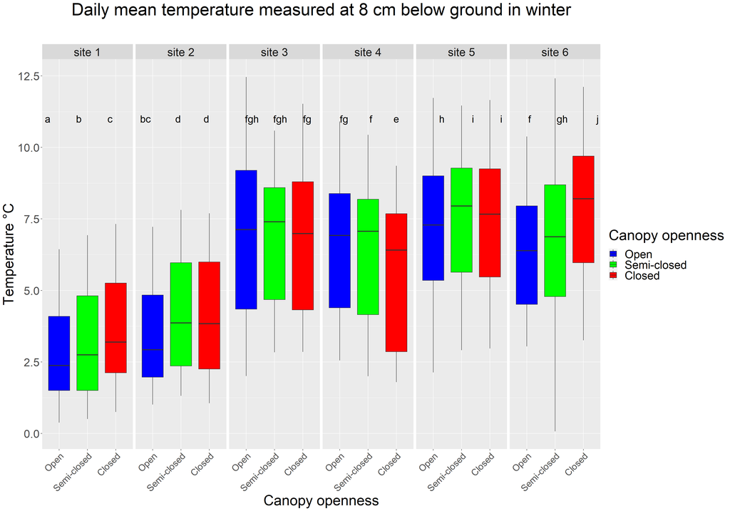

### 4.1.2 Daily maximum temperature measured at 8 cm below ground in Winter

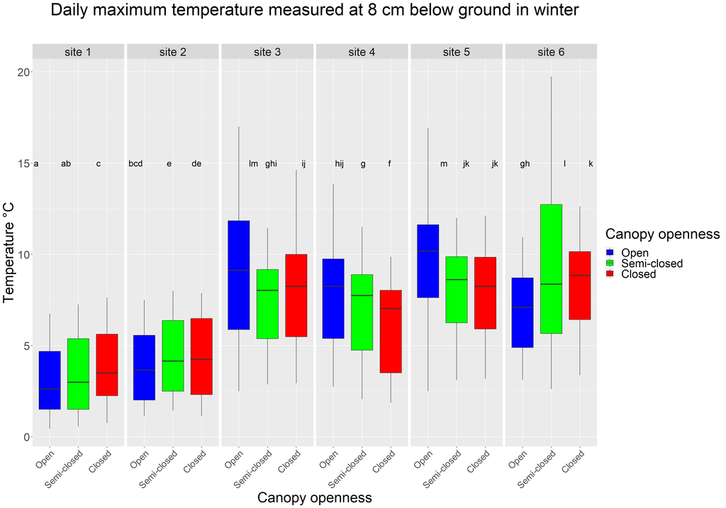

### 4.1.3 Daily minimum temperature measured at 8 cm below ground in Winter

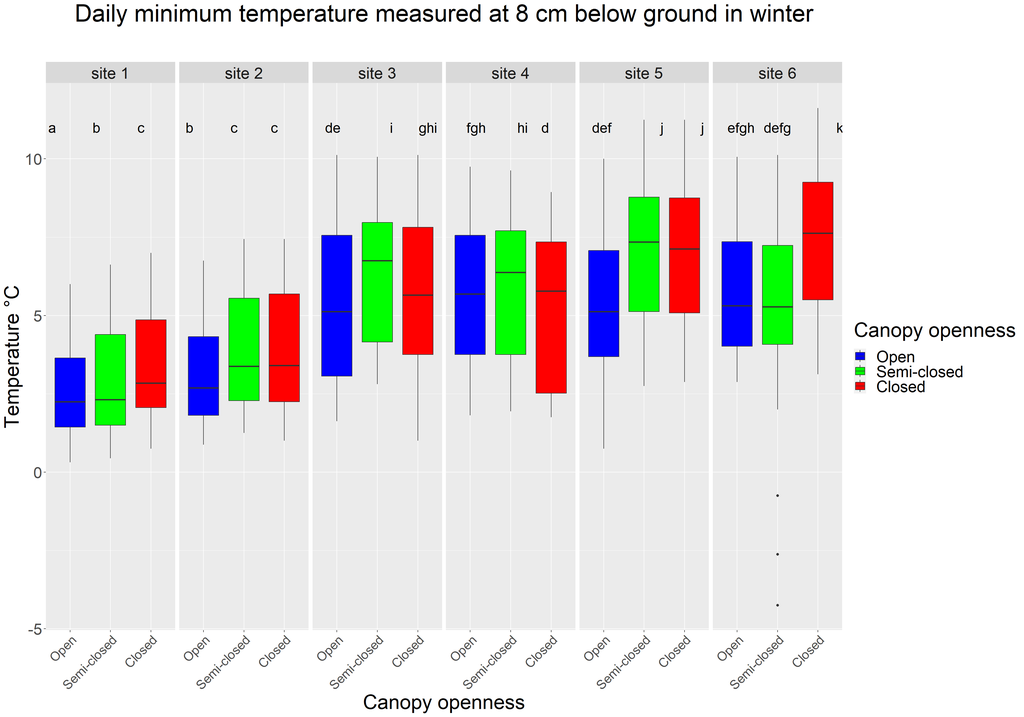

### 4.1.4 Daily mean temperature measured at 15 cm above ground in winter

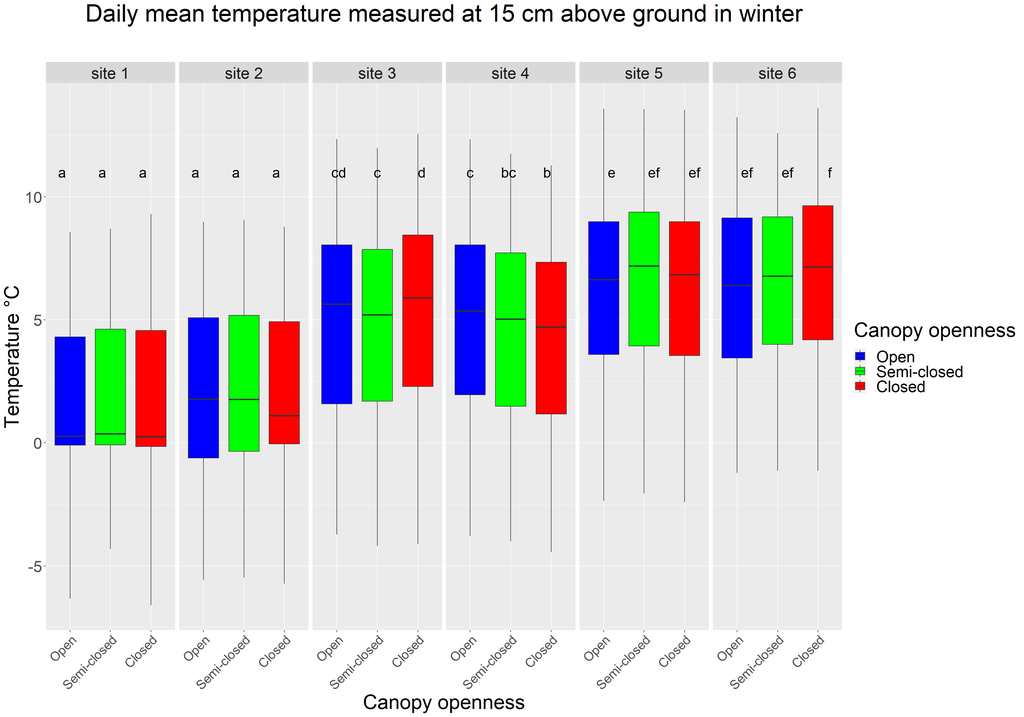

### 4.1.5 Daily maximum temperature measured at 15 cm above ground in winter

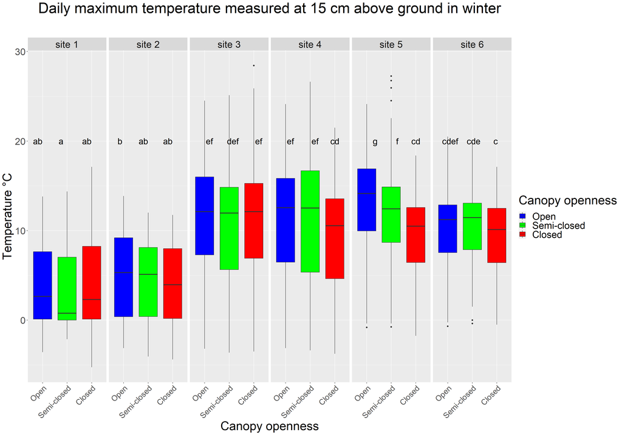

### 4.1.6 Daily minimum temperature measured at 15 cm above ground in winter

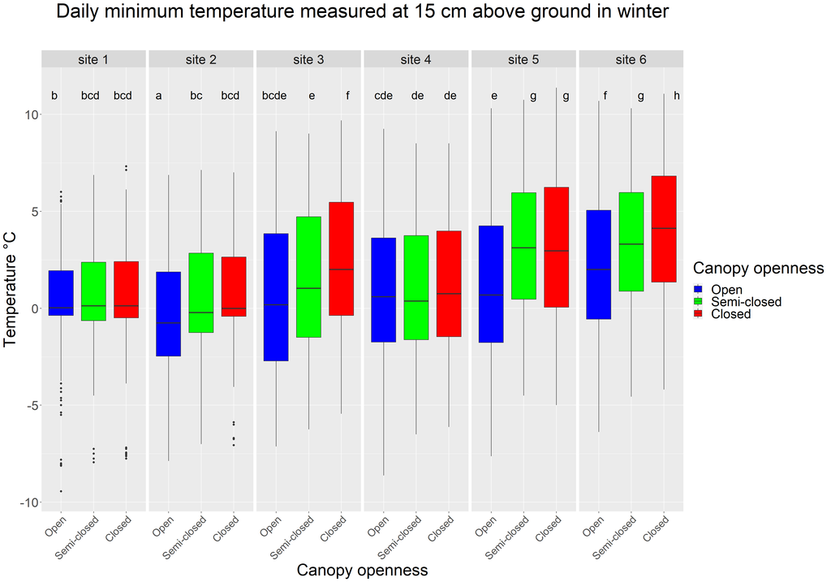

## 4.2 Summer

### 4.2.1 Daily mean temperature measured at 8 cm below ground in Summer

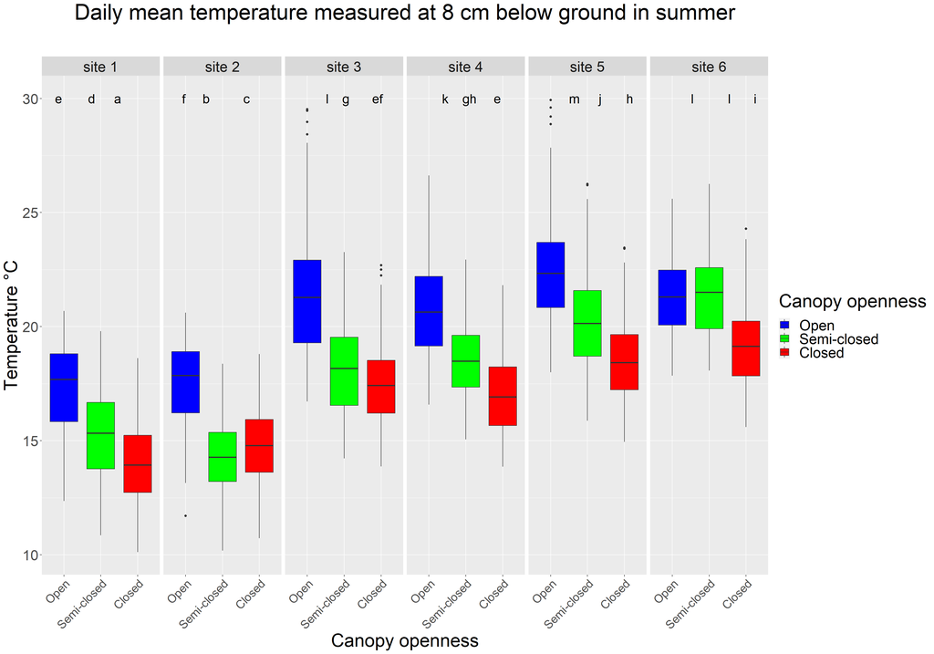

### 4.2.2 Daily maximum temperature measured at 8 cm below ground in Summer

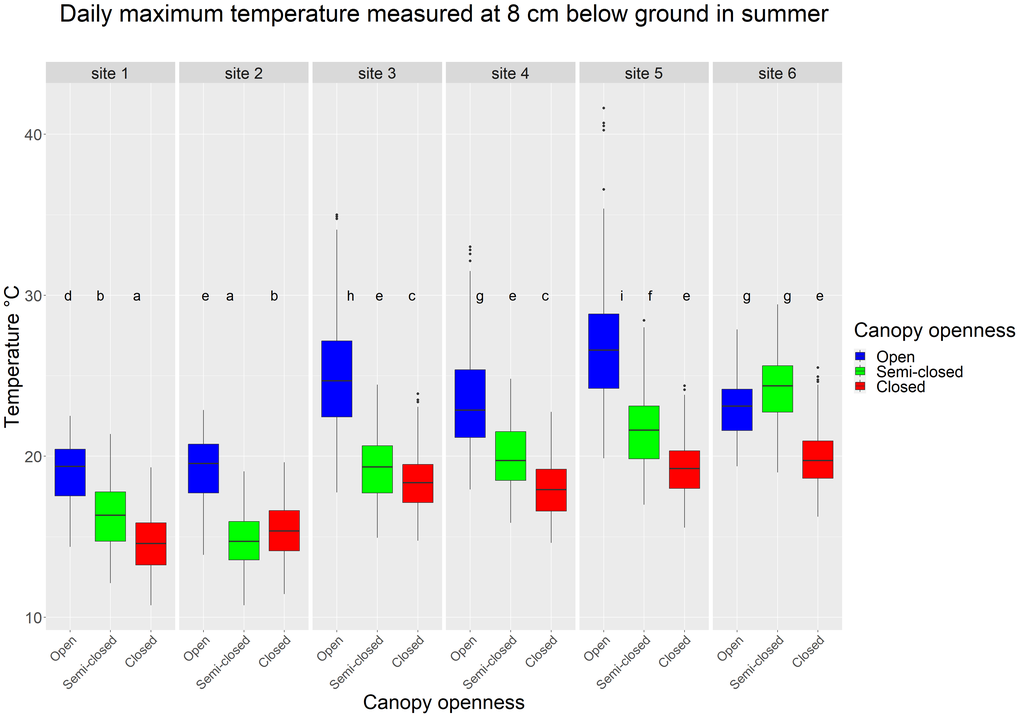

### 4.2.3 Daily minimum temperature measured at 8 cm below ground in Summer

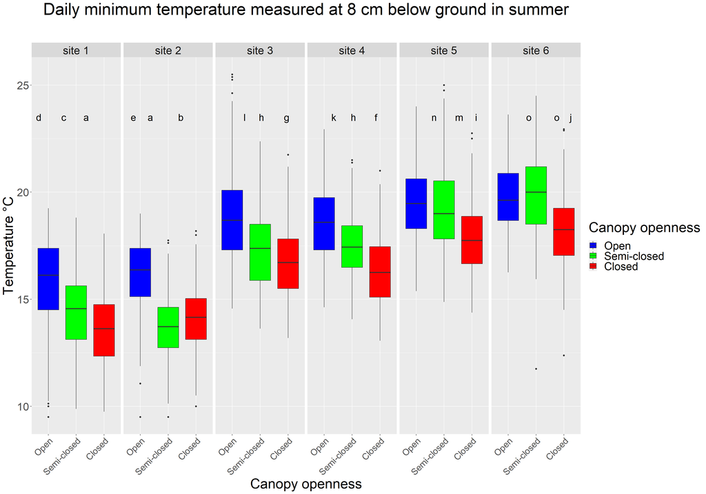

### 4.2.4 Daily mean temperature measured at 15 cm above ground in Summer

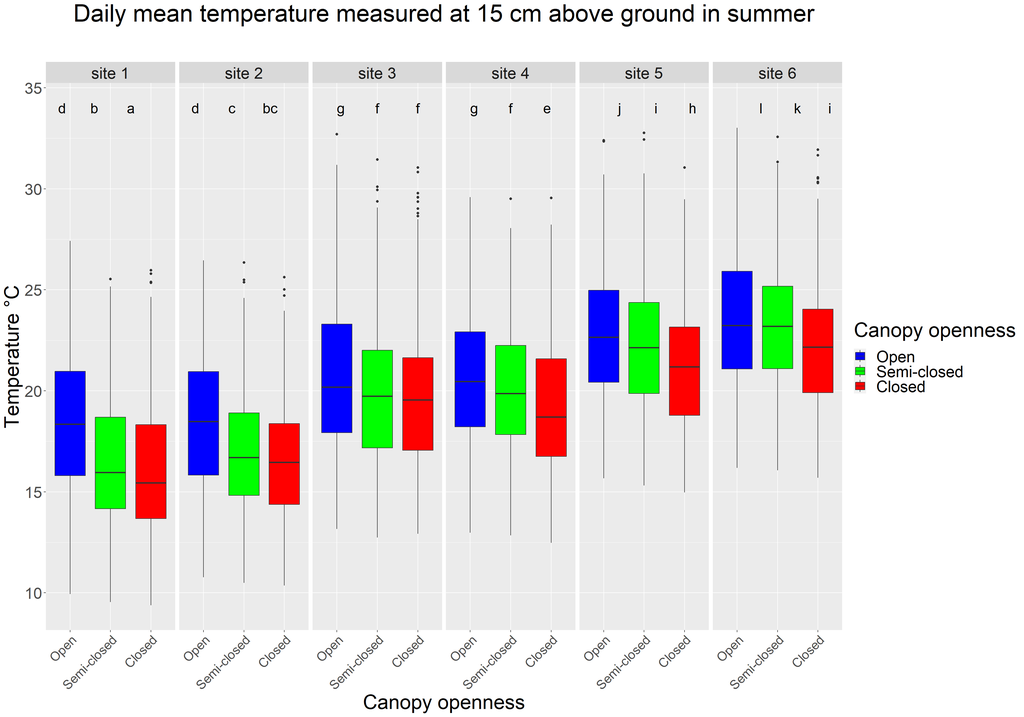

### 4.2.5 Daily maximum temperature measured at 15 cm above ground in Summer

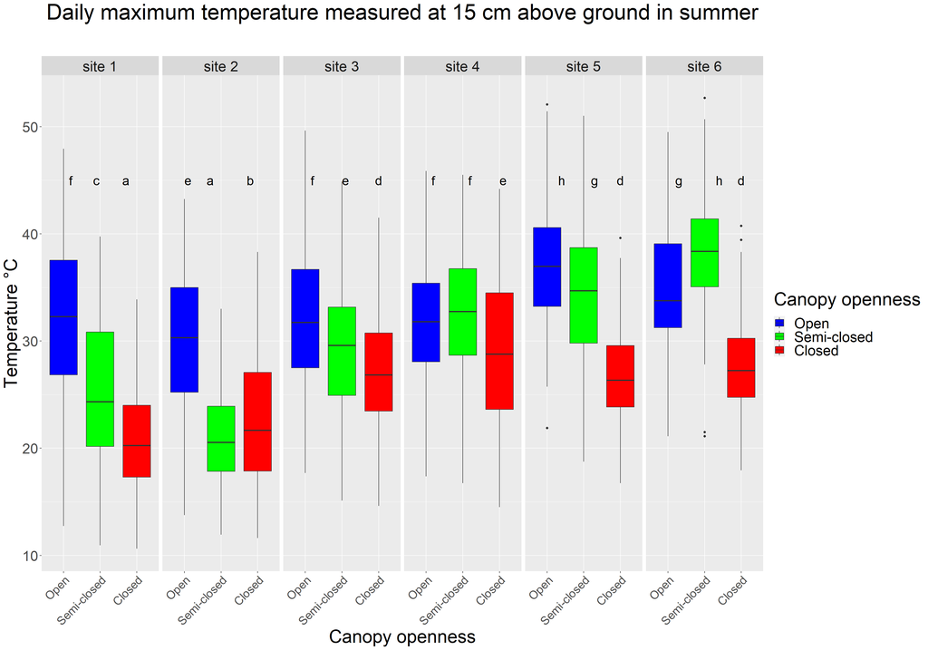

### 4.2.6 Daily minimum temperature measured at 15 cm above ground in Summer

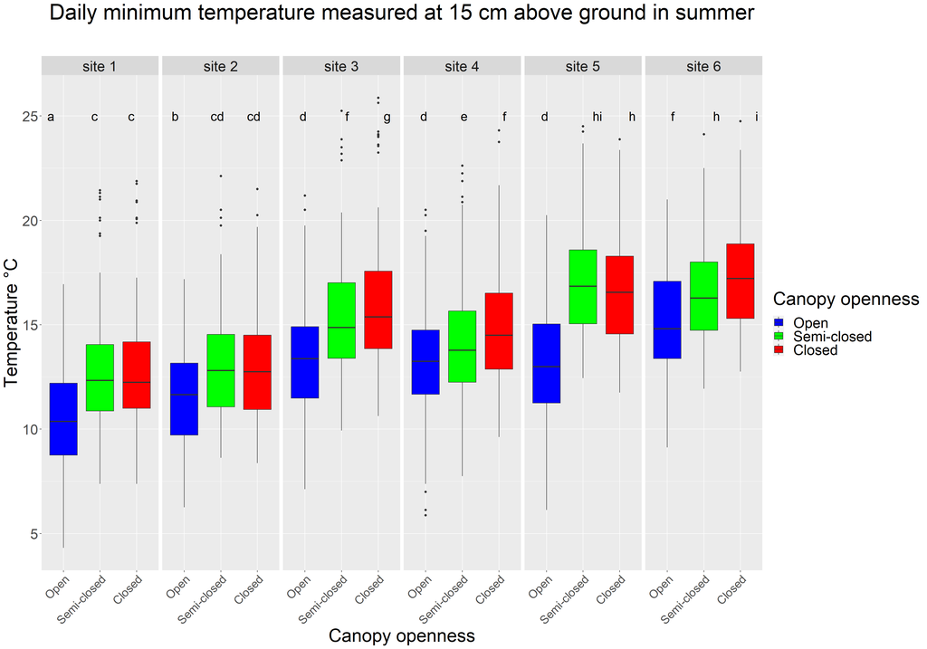